# The Normal & Sampling

SPEA V706 · Math Camp

Coady Wing

## The Plan

- One distribution we will lean on constantly: the **Normal**, pinned down by just its mean and variance
- Then the move from **population to sample** — the split between an estimand and an estimator
- Two properties of an estimator we care about: is it aimed right (**bias**), and is it tight (**sampling variance**)?
- The running case is the humblest estimator there is, the **sample mean** — and it sets up the two limit theorems next session

## The Normal Distribution

## The Normal Distribution

- The **Normal** $N(\mu, \sigma^2)$ is the familiar bell curve, pinned down by just its mean and variance
- It is symmetric, and it is completely described by those first two moments
- We lean on it constantly — for confidence intervals, $t$-statistics, and $p$-values
- Why does *this one* distribution keep reappearing? A theorem next session explains it; the world itself is under no obligation to be bell-shaped

## A Real Variable, Roughly Bell-Shaped

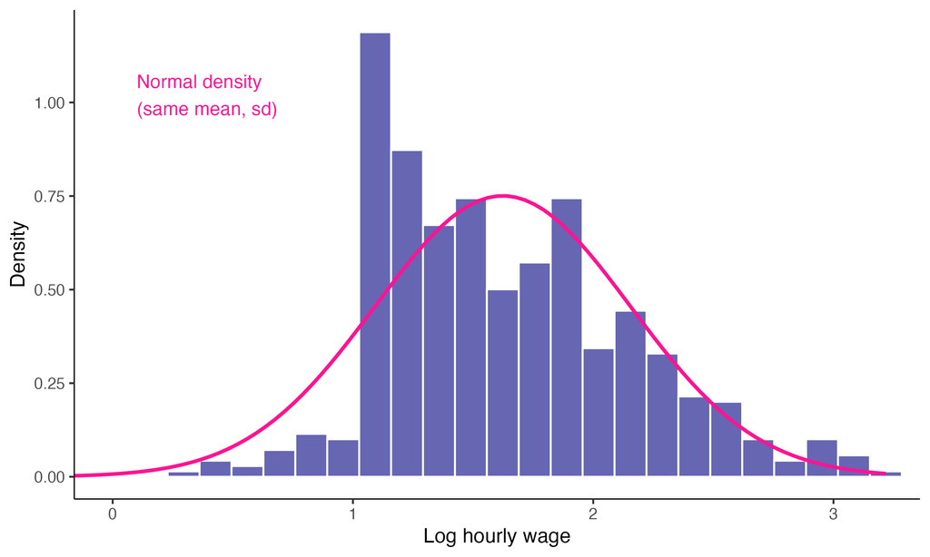

- Log hourly wages for 526 workers (1976 CPS), with a Normal density laid on top — same mean, same standard deviation
- The fit is not perfect, but the shape is close: many real variables are roughly bell-shaped

## From Populations to Samples

## Estimand vs. Estimator

- An **estimand** is the population quantity we want to learn — say $E[Y]$, a fixed number, a feature of the DGP
- An **estimator** is a recipe that turns a sample into a guess at the estimand
- The estimator is a **random variable**: feed it a different sample, get a different number
- Keep the two straight — the estimand is the target, the estimator is the arrow

## The Sample Mean as an Estimator

- Our estimand is the population mean $E[Y]$
- Its natural sample analog just **replaces the expectation with an average** over the $n$ observations:

$$\bar Y_n = \frac{1}{n} \sum_{i=1}^{n} Y_i$$

- The subscript $i$ marks a **sample** quantity: $Y_1, \dots, Y_n$ are the draws we actually observe
- This “replace expectations with averages” move is the template for nearly every estimator we build

## Bias: Is the Arrow Aimed Right?

- The **bias** of an estimator is how far off it is *on average* across repeated samples:

$$\operatorname{Bias}(\hat\theta) = E[\hat\theta] - \theta$$

- The sample mean is **unbiased** for $E[Y]$ — pull the expectation through the average and each term is $\mu$:

$$E[\bar Y_n] = \frac{1}{n} \sum_{i=1}^{n} E[Y_i] = \mu$$

- On average, over many samples, the sample mean lands right on the population mean

## Sampling Variance: How Wide Is the Spread?

- Unbiased is not enough — we also want the estimator to be **tight** around the target
- With iid draws (independent, each with variance $\sigma^2$), the variances add, and the $1/n$ out front gets squared:

$$\operatorname{Var}(\bar Y_n) = \frac{\sigma^2}{n}$$

- More data shrinks the sampling variance toward zero — the estimator gets **sharper** as $n$ grows
- That $\sigma^2 / n$ is the seed of both theorems we close with next session

## Recap

- The **Normal** $N(\mu, \sigma^2)$ is the bell curve fixed by its first two moments; many real variables are roughly bell-shaped
- An **estimand** is the population target; an **estimator** is a sample recipe aimed at it, and it is itself a random variable
- The **sample mean** is unbiased for $E[Y]$, with sampling variance $\sigma^2 / n$ that shrinks as the sample grows
- That $\sigma^2 / n$ is exactly what the **Law of Large Numbers** and the **Central Limit Theorem** are about — next session